# Explorando o pacote Get DFP Data

2021-03-08

```r
knitr::opts_chunk$set(echo = T,
                      warning = F,
                      message = F,
                      fig.align = "center")
```

A utilização de dados financeiros de empresas públicas é algo comum para investidores que querem verificar a performance de alguma empresa ou estudantes que estão desenvolvendo artigos sobre finanças corporativas. O acesso a estes dados não é tão trivial, porém algumas empresas, como é o caso da Economatica, auxiliam nesta tarefa, consolidando os dados financeiros e permitindo a exportação em um formato amigável para ser analisado.

Apesar da facilidade, o acesso pela Economatica não é gratuito e isso inviabiliza o acesso por estudantes principalmente. Uma alternativa que parece bastante promissora é a ferramenta [GetDFPData](https://www.msperlin.com/shiny/GetDFPData2/), desenvolvida pelo Professor Marcelo Perlin da UFRGS. De maneira resumida, esta ferramenta realiza chamadas API no repositório da B3, retornando o arquivo (.xslx) com os dados financeiros da empresa que você solicita, no período indicado, podendo ser esta solicitação via GUI ou usando funções no R que são disponibilizadas após instalar o pacote ‘GetDFPData2’. Mais detalhes de seu funcionamento podem ser encontrado neste [artigo](http://bibliotecadigital.fgv.br/ojs/index.php/rbfin/article/view/78654) feito pelo próprio Professor Marcelo.

O artigo indica que problemas de qualidade dos dados podem existir, pois ela apenas retorna dados que são inseridos na B3 pelas empresas, portanto neste artigo vou listar alguns problemas de qualidade dos dados e formas que eles podem ser tratados com o R, para que se tenha um dataset final pronto para ser explorado.

O pacote está em fase de desenvolvimento, podendo ser instaldo via devtools:

```r
library(devtools)
devtools::install_github("msperlin/GetDFPData2")
```

Após instalar o pacote, vou trazê-lo para o ambiente junto com o tidyverse, para me auxiliar na manipulação dos dados.

```r
library(tidyverse)
library(GetDFPData2)
```

Para trazer o dataset financeiro, basta executar o comando abaixo, que irá solicitar o ano de início, fim e o tipo de informação (e.g. DRE, BP). No comando abaixo, eu solicito o dataset referente à DRE de todas as empresas disponíveis, de 2010 até 2020 e em seguida salvo este dataset em formato ‘.csv’.

```r
dataset_original <- GetDFPData2::get_dfp_data(
                          first_year = "2010",
                          last_year = "2020",
                          type_docs = "DRE")




# Note a utilização do Encoding para preservar os acentos
write.csv(x = dataset_original$`DF Individual - Demonstração do Resultado`,
          file = "C:/Users/fppicco/Desktop/R/Github/franciscopiccolo.github.io/datasets/2021-03-10-financial_dataset_b3_getdfpdata_package/dataset_2.csv",
          fileEncoding = "latin1")
```

Agora basta fazer a leitura do arquivo ‘.csv’ para poder fazer a análise exploratória.

```r
# Novamente, mantendo o encoding na hora da leitura
dataset <-
  read.csv(file = "C:/Users/fppicco/Desktop/R/Github/franciscopiccolo.github.io/datasets/2021-03-10-financial_dataset_b3_getdfpdata_package/dataset_2.csv",
           encoding = "latin1")
```

Vamos ver os campos deste dataset e os tipos de dados.

```r
# Números de registros e quantodade de colunas
dataset %>%
  dim()
```

```
## [1] 218420     17
```

```r
# Tipos de dados
dataset %>%
  str()
```

```
## 'data.frame':    218420 obs. of  17 variables:
##  $ X           : int  1 2 3 4 5 6 7 8 9 10 ...
##  $ CNPJ_CIA    : chr  "00.000.000/0001-91" "00.000.000/0001-91" "00.000.000/0001-91" "00.000.000/0001-91" ...
##  $ CD_CVM      : int  1023 1023 1023 1023 1023 1023 1023 1023 1023 1023 ...
##  $ DT_REFER    : chr  "2010-12-31" "2010-12-31" "2010-12-31" "2010-12-31" ...
##  $ DT_INI_EXERC: chr  "2010-01-01" "2010-01-01" "2010-01-01" "2010-01-01" ...
##  $ DT_FIM_EXERC: chr  "2010-12-31" "2010-12-31" "2010-12-31" "2010-12-31" ...
##  $ DENOM_CIA   : chr  "BCO BRASIL S.A." "BCO BRASIL S.A." "BCO BRASIL S.A." "BCO BRASIL S.A." ...
##  $ VERSAO      : int  3 3 3 3 3 3 3 3 3 3 ...
##  $ GRUPO_DFP   : chr  "DF Individual - Demonstração do Resultado" "DF Individual - Demonstração do Resultado" "DF Individual - Demonstração do Resultado" "DF Individual - Demonstração do Resultado" ...
##  $ MOEDA       : chr  "REAL" "REAL" "REAL" "REAL" ...
##  $ ESCALA_MOEDA: chr  "MIL" "MIL" "MIL" "MIL" ...
##  $ ORDEM_EXERC : chr  "ÚLTIMO" "ÚLTIMO" "ÚLTIMO" "ÚLTIMO" ...
##  $ CD_CONTA    : chr  "3.01" "3.01.01" "3.01.02" "3.01.03" ...
##  $ DS_CONTA    : chr  "Receitas da Intermediação Financeira" "Operações de Crédito" "Operações de Arrendamento Mercantil" "Resultado de Operações com TVM" ...
##  $ VL_CONTA    : num  72173904 47391099 40372 21574907 -1231410 ...
##  $ COLUNA_DF   : logi  NA NA NA NA NA NA ...
##  $ source_file : chr  "dfp_cia_aberta_DRE_ind_2010.csv" "dfp_cia_aberta_DRE_ind_2010.csv" "dfp_cia_aberta_DRE_ind_2010.csv" "dfp_cia_aberta_DRE_ind_2010.csv" ...
```

Veja que há campos de data (e.g. ‘DT_REFER’) classificada como ‘chr’, porém deveria ser date. Vamos aplicar a mudança com o código abaixo.

```r
dataset %>%
  mutate(DT_REFER = as.Date(DT_REFER),
         DT_INI_EXERC = as.Date(DT_INI_EXERC),
         DT_FIM_EXERC = as.Date(DT_FIM_EXERC)) -> dataset
```

Conferindo o ajuste com a função ‘str()’

```r
dataset %>% str()
```

```
## 'data.frame':    218420 obs. of  17 variables:
##  $ X           : int  1 2 3 4 5 6 7 8 9 10 ...
##  $ CNPJ_CIA    : chr  "00.000.000/0001-91" "00.000.000/0001-91" "00.000.000/0001-91" "00.000.000/0001-91" ...
##  $ CD_CVM      : int  1023 1023 1023 1023 1023 1023 1023 1023 1023 1023 ...
##  $ DT_REFER    : Date, format: "2010-12-31" "2010-12-31" ...
##  $ DT_INI_EXERC: Date, format: "2010-01-01" "2010-01-01" ...
##  $ DT_FIM_EXERC: Date, format: "2010-12-31" "2010-12-31" ...
##  $ DENOM_CIA   : chr  "BCO BRASIL S.A." "BCO BRASIL S.A." "BCO BRASIL S.A." "BCO BRASIL S.A." ...
##  $ VERSAO      : int  3 3 3 3 3 3 3 3 3 3 ...
##  $ GRUPO_DFP   : chr  "DF Individual - Demonstração do Resultado" "DF Individual - Demonstração do Resultado" "DF Individual - Demonstração do Resultado" "DF Individual - Demonstração do Resultado" ...
##  $ MOEDA       : chr  "REAL" "REAL" "REAL" "REAL" ...
##  $ ESCALA_MOEDA: chr  "MIL" "MIL" "MIL" "MIL" ...
##  $ ORDEM_EXERC : chr  "ÚLTIMO" "ÚLTIMO" "ÚLTIMO" "ÚLTIMO" ...
##  $ CD_CONTA    : chr  "3.01" "3.01.01" "3.01.02" "3.01.03" ...
##  $ DS_CONTA    : chr  "Receitas da Intermediação Financeira" "Operações de Crédito" "Operações de Arrendamento Mercantil" "Resultado de Operações com TVM" ...
##  $ VL_CONTA    : num  72173904 47391099 40372 21574907 -1231410 ...
##  $ COLUNA_DF   : logi  NA NA NA NA NA NA ...
##  $ source_file : chr  "dfp_cia_aberta_DRE_ind_2010.csv" "dfp_cia_aberta_DRE_ind_2010.csv" "dfp_cia_aberta_DRE_ind_2010.csv" "dfp_cia_aberta_DRE_ind_2010.csv" ...
```

Agora vamos verificar se o dataset contém valores duplicados, para isso, é preciso remover a primeira coluna, que é uma coluna índice que vai do 1 até a última linha. Com ela, não será possível captar nenhuma linha repitida.

```r
# Conferindo se há duplicadas
dataset %>%
  select(-1) %>%  # retirando o primeiro campo da seleção
  distinct_all() %>%
  dim()
```

```
## [1] 217191     16
```

```r
# Salvando dataset após remoção das duplicadas
dataset <-
  dataset %>%
  select(-1) %>%
  distinct_all()
```

## Quantidade de CNPJs no dataset

```r
dataset %>%
  distinct(CNPJ_CIA) %>%
  dim()
```

```
## [1] 961   1
```

### Quantidade de CNPJs por anos de dados disponíveis

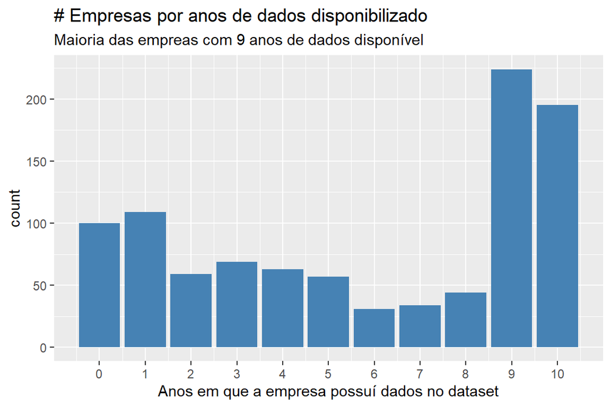

```r
dataset %>%
  #filter(lubridate::year(DT_FIM_EXERC) != "2020") %>%
  select(DENOM_CIA, DT_INI_EXERC, DT_FIM_EXERC) %>%
  group_by(DENOM_CIA) %>%
  summarise(first_year = lubridate::year(min(DT_INI_EXERC)),
            last_year = lubridate::year(max(DT_FIM_EXERC))) %>%
  mutate(diff = last_year-first_year) %>%
  group_by(diff) %>%
  summarise(count = n()) %>%
  ggplot2::ggplot()+
  geom_col(mapping = aes(x = diff, y = count),
           fill = "steel blue")+
  scale_x_continuous(breaks = seq(0,10,by = 1))+
  labs(title = "# Empresas por anos de dados disponibilizado",
       subtitle = "Maioria das empreas com 9 anos de dados disponível",
       x = "Anos em que a empresa possuí dados no dataset")
```

## Quantidade de métricas no dataset

```r
dataset %>%
  distinct(CD_CONTA) %>%
  dim()
```

```
## [1] 237   1
```

```r
dataset %>%
  distinct(DS_CONTA) %>%
  dim()
```

```
## [1] 3126    1
```

```r
dataset %>%
  #filter(lubridate::year(DT_FIM_EXERC) != "2020") %>%
  select(DENOM_CIA, CD_CONTA, DT_INI_EXERC, DT_FIM_EXERC) %>%
  group_by(DENOM_CIA, CD_CONTA) %>%
  summarise(first_year = lubridate::year(min(DT_INI_EXERC)),
            last_year = lubridate::year(max(DT_FIM_EXERC))) %>%
  mutate(diff = last_year-first_year) %>%
  group_by(diff, CD_CONTA) %>%
  summarise(count = n()) %>%
  mutate(share = count/960) %>%
  View()
```